# Graph analytics in Spark

# 1 Introduction

Graphs are data structures composed of nodes and edges

- nodes/vertexes are denoted as $V=\{v_1,v_2,...,v_n\}$
- edges are denoted as $E=\{e_1,e_2,...,e_n\}$

Graph analytics is the process of analyzing relationships between vertexes and edges.

Example of graph

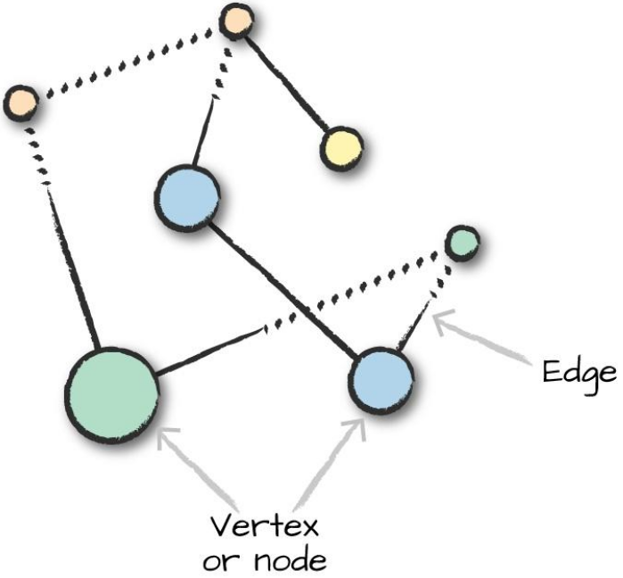

Graphs are called **undirected** if edges do not have a direction, otherwise they are called **directed** graphs. Vertexes and edges can have data associated with them

- weights are associated to edges (e.g., they may represent the strength of the relationship);
- labels are associated to vertexes (e.g., they may be the string associated with the name of the vertex).

Graph with labels and weights

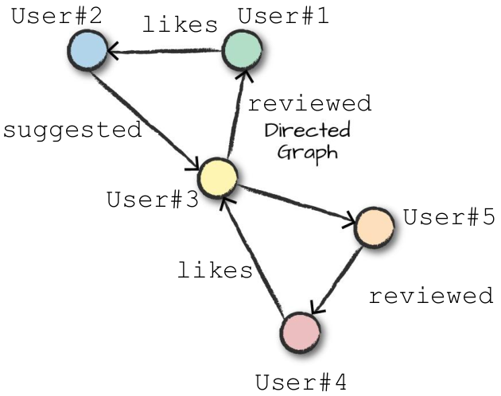

**Why graph analytics?**

Graphs are natural way of describing relationships. Some practical example of analytics over graphs

- Ranking web pages (Google PageRank)

Pages in the web

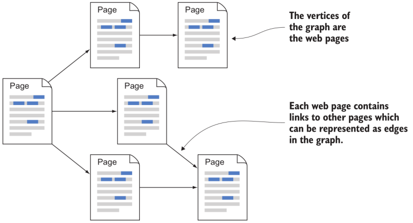

- Detecting group of friends

Social networks

[figure not shown]

Movies watched by users

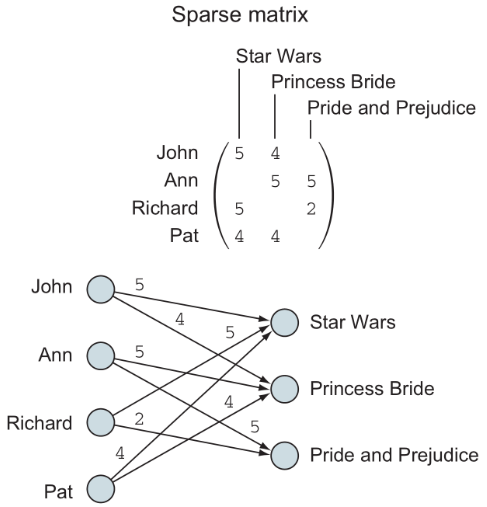

- Determine importance of infrastructure in electrical networks
- …

# 2 Spark GraphX and GraphFrames

GraphX is the Spark RDD-based library for performing graph processing. It is a core part of Spark.

Spark core libraries

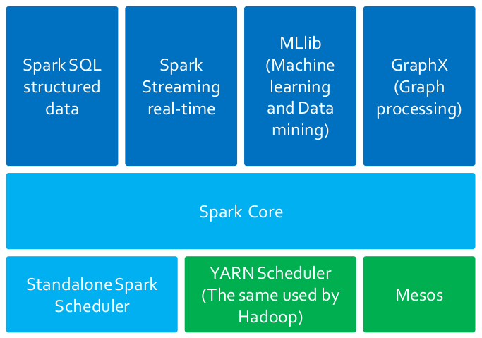

GraphX

- is low level interface with RDD
- is very powerful: many application and libraries built on top of it
- is not easy to use or optimize
- has no Python version of the APIs

[GraphFrames](https://graphframes.github.io/graphframes/docs/_site/index.html) is a library DataFrame-based for performing graph processing. It is a Spark external package built on top of GraphX.

GraphFrame structure

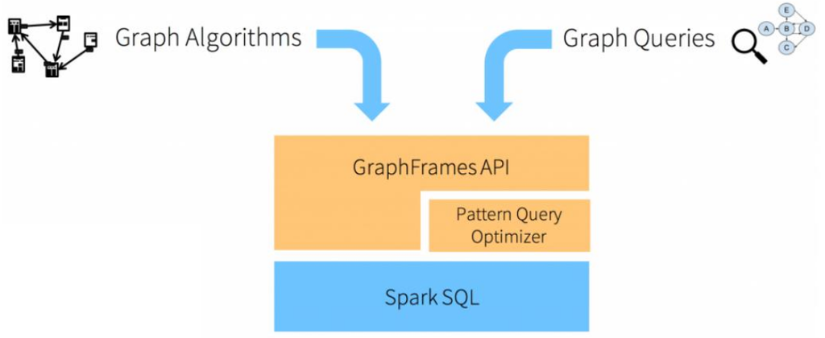

# 3 Building and querying graphs with GraphFrames

## 3.1 Building a Graph

Define vertexes and edges of the graph: vertexes and edges are represented by means of records inside DataFrames with specifically named columns

- One DataFrame for the definition of the vertexes of the graph. The DataFrames that are used to represent nodes/vertexes
  - Contain one record per vertex
  - Must contain a column named “id” that stores unique vertex IDs
  - Can contain other columns that are used to characterize vertexes
- One DataFrame for the definition of the edges of the graph. The DataFrames that are used to represent edges
  - Contain one record per edge
  - Must contain two columns “src” and “dst” storing source vertex IDs and destination vertex IDs of edges
  - Can contain other columns that are used to characterize edges

Create a graph of type `graphframes.graphframe.GraphFrame` by invoking the constructor `GraphFrame(v,e)`

- `v`: the DataFrame containing the definition of the vertexes
- `e`: the DataFrame containing the definition of the edges

Graphs in graphframes are directed graphs.

Building a graph example

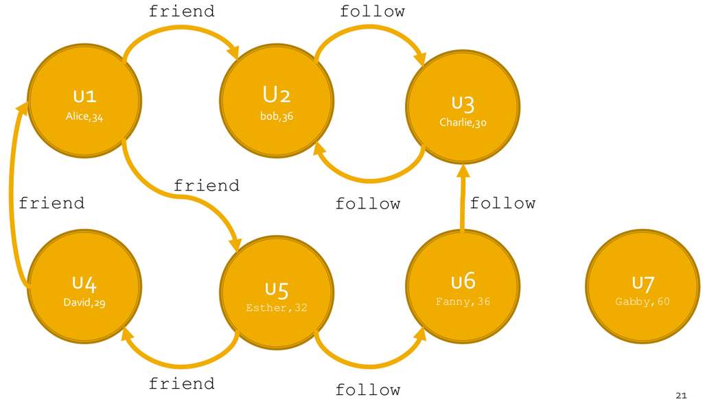

**Example**

Given this Vertex DataFrame

| id | name | age |
| --- | --- | --- |
| u1 | Alice | 34 |
| u2 | Bob | 36 |
| u3 | Charlie | 30 |
| u4 | David | 29 |
| u5 | Esther | 32 |
| u6 | Fanny | 36 |
| u7 | Gabby | 60 |

And this Edge DataFrame

| src | dst | relationship |
| --- | --- | --- |
| u1 | u2 | friend |
| u2 | u3 | follow |
| u3 | u2 | follow |
| u6 | u3 | follow |
| u5 | u6 | follow |
| u5 | u4 | friend |
| u4 | u1 | friend |
| u1 | u5 | friend |

```python
from graphframes import GraphFrame

# Vertex DataFrame
v = spark.createDataFrame(
    [
        ("u1", "Alice", 34),
        ("u2", "Bob", 36),
        ("u3", "Charlie", 30),
        ("u4", "David", 29),
        ("u5", "Esther", 32),
        ("u6", "Fanny", 36),
        ("u7", "Gabby", 60)
    ],
    ["id", "name", "age"]
)

# Edge DataFrame
e = spark.createDataFrame(
    [
        ("u1", "u2", "friend"),
        ("u2", "u3", "follow"),
        ("u3", "u2", "follow"),
        ("u6", "u3", "follow"),
        ("u5", "u6", "follow"),
        ("u5", "u4", "friend"),
        ("u4", "u1", "friend"),
        ("u1", "u5", "friend")
    ],
    ["src", "dst", "relationship"]
)

# Create the graph
g = GraphFrame(v, e)
```

## 3.3 Cache graphs

As with RDD and DataFrame, it is possible to cache graphs in GraphFrame: it is convenient if the same (complex) graph result of (multiple) transformations is used multiple times in the same application. To do it, simply invoke `cache()` on the GraphFrame to cache, so that it persists the DataFrame-based representation of vertexes and edges of the graph.

## 3.4 Querying the graph

Some specific methods are provided to execute queries on graphs

- `filterVertices(condition)`
- `filterEdges(condition)`
- `dropIsolatedVertices()`

The returned result is the filtered version of the input graph.

### 3.4.1 `filterVertices(condition)`

`filterVertices(condition)` selects only the vertexes for which the specified condition is satisfied and returns a new graph with only the subset of selected vertexes.

`condition` contains an SQL-like condition on the values of the attributes of the vertexes (e.g., “age>35”).

### 3.4.2 `filterEdges(condition)`

`filterEdges(condition)` selects only the edges for which the specified condition is satisfied and returns a new graph with only the subset of selected edges.

`condition` contains an SQL-like condition on the values of the attributes of the edges (e.g., “relationship=‘friend’”).

### 3.4.3 `dropIsolatedVertices()`

`dropIsolatedVertices()` drops the vertexes that are not connected with any other node and returns a new graph without the dropped nodes.

**Example**

Given the input graph, create a new subgraph

Input graph

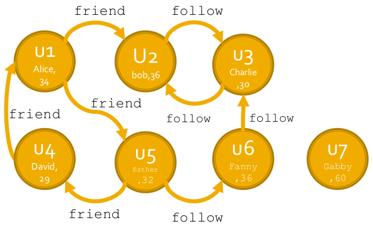

1. Include only the vertexes associated with users characterized by age between 29 and 50

Filter vertexes

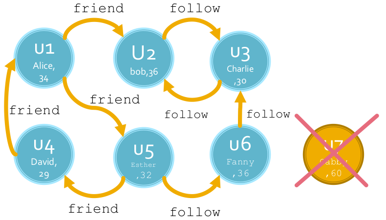

2. Include only the edges representing the friend relationship

Filter edges

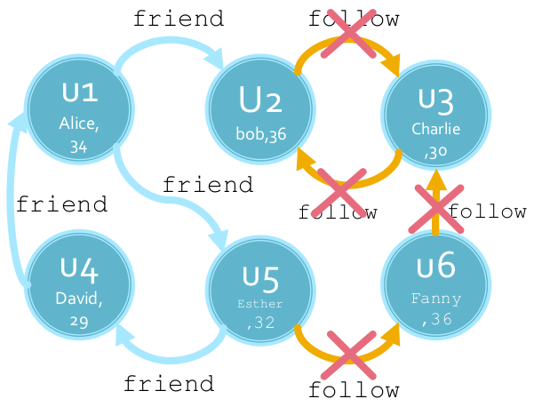

3. Drop isolated vertexes

Drop isolated vertices

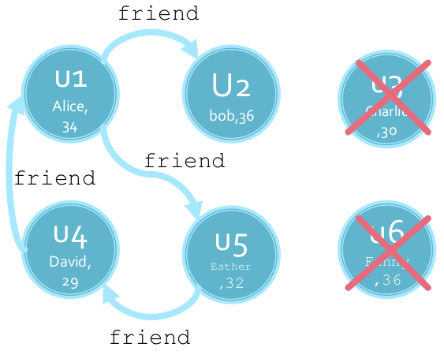

Output graph

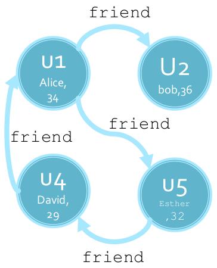

```python
from graphframes import GraphFrame

# Vertex DataFrame
v = spark.createDataFrame(
    [
        ("u1", "Alice", 34),
        ("u2", "Bob", 36),
        ("u3", "Charlie", 30),
        ("u4", "David", 29),
        ("u5", "Esther", 32),
        ("u6", "Fanny", 36),
        ("u7", "Gabby", 60)
    ],
    ["id", "name", "age"]
)

# Edge DataFrame
e = spark.createDataFrame(
    [
        ("u1", "u2", "friend"),
        ("u2", "u3", "follow"),
        ("u3", "u2", "follow"),
        ("u6", "u3", "follow"),
        ("u5", "u6", "follow"),
        ("u5", "u4", "friend"),
        ("u4", "u1", "friend"),
        ("u1", "u5", "friend")
    ],
    ["src", "dst", "relationship"]
)

# Create the graph
g = GraphFrame(v, e)

selectedUsersandFriendRelGraph = g \
    .filterVertices("age>=29 AND age<=50") \
    .filterEdges("relationship='friend'") \
    .dropIsolatedVertices()
```

Given a GraphFrame, it is possible to access its vertexes and edges

- `g.vertices` returns the DataFrame associated with the vertexes of the input graph
- `g.edges` returns the DataFrame associated with the edges of the input graph

All the standard DataFrame transformations/actions are available also for the DataFrames that are used to store vertexes and edges. For example, the number of vertexes and the number of edges can be computed by invoking the `count()` action on the DataFrames vertices and edges, respectively.

**Example**

Given the input graph

1. Count how many vertexes and edges has the graph
2. Find the smallest value of age (i.e., the age of the youngest user in the graph)
3. Count the number of edges of type “follow” in the graph

```python
from graphframes import GraphFrame

# Vertex DataFrame
v = spark.createDataFrame(
    [
        ("u1", "Alice", 34),
        ("u2", "Bob", 36),
        ("u3", "Charlie", 30),
        ("u4", "David", 29),
        ("u5", "Esther", 32),
        ("u6", "Fanny", 36),
        ("u7", "Gabby", 60)
    ],
    ["id", "name", "age"]
)

# Edge DataFrame
e = spark.createDataFrame(
    [
        ("u1", "u2", "friend"),
        ("u2", "u3", "follow"),
        ("u3", "u2", "follow"),
        ("u6", "u3", "follow"),
        ("u5", "u6", "follow"),
        ("u5", "u4", "friend"),
        ("u4", "u1", "friend"),
        ("u1", "u5", "friend")
    ],
    ["src", "dst", "relationship"]
)

# Create the graph
g = GraphFrame(v, e)

# Count how many vertexes and edges has the graph
print("Number of vertexes: ",g.vertices.count())
print("Number of edges: ",g.edges.count())

# Print on the standard output the smallest value of age
# (i.e., the age of the youngest user in the graph)
g.vertices.agg({"age":"min"}).show()

# Print on the standard output
# the number of "follow" edges in the graph.
numFollows = g.edges.filter("relationship = 'follow' ").count()

print(numFollows)
```

[output not shown]

## 3.5 Motif finding

Motif finding refers to searching for structural patterns in graphs. A simple Domain-Specific Language (DSL) is used to specify the structure of the interesting patterns: the paths/subgraphs in the graph matching the specified structural pattern are selected.

### 3.5.1 DSL for Motif finding

The basic unit of a pattern is a connection between vertexes

$$(v1) – [e1] \rightarrow (v2)$$

means: an arbitrary edge [e1] from an arbitrary vertex (v1) to another arbitrary vertex (v2)

- Edges are denoted by square brackets: $[e1]$
- Vertexes are expressed by round brackets: $(v1)$, $(v2)$

Basic unit

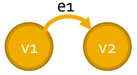

Patterns are chains of basic units

$$(v1) – [e1] \rightarrow (v2);\quad (v2) – [e2] \rightarrow (v3)$$

means: an arbitrary edge from an arbitrary vertex $v1$ to another arbitrary vertex $v2$ and another arbitrary edge from $v2$ to another arbitrary vertex $v3$. Notice that $v3$ and $v1$ can be the same vertex.

Basic unit chaining

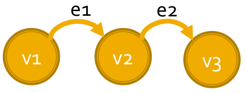

The same vertex name is used in a pattern to have a reference to the same vertex

$$(v1) – [e1] \rightarrow (v2);\quad (v2) – [e2] \rightarrow (v1)$$

means: an arbitrary edge from an arbitrary vertex $v1$ to another arbitrary vertex $v2$ and vice-versa.

Basic unit self-chaining

[figure not shown]

It is acceptable to omit names for vertices or edges in patterns when not needed

$$(v1)-[\quad]\rightarrow(v2)$$

means: an arbitrary edge between two arbitrary vertexes $v1$, $v2$, but does not assign a name to the edge. These are called **anonymous** vertexes and edges.

Anonymous vertexes and edges

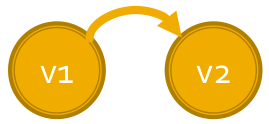

A basic unit (an edge between two vertexes) can be negated to indicate that the edge should not be present in the graph

$$(v1)-[\quad]\rightarrow(v2);\quad !(v2)-[\quad]\rightarrow(v1)$$

means: edges from $v1$ to $v2$ but no edges from $v2$ to $v1$.

Negating edges

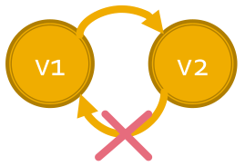

The `find(motif)` method of GraphFrame is used to select motifs

- `motif` is a DSL representation of the structural pattern

`find()` returns a DataFrame of all the paths matching the structural motif/pattern, one path per record. The returned DataFrame will have a column for each of the named elements (vertexes and edges) in the structural pattern/motif: Each column is a struct, and the fields of each struct are the labels/features of the associated vertex or edge. It can return duplicate rows/records, if there are many paths connecting the same nodes.

More complex queries on the structure and content of the patterns can be expressed by applying filters to the result DataFrame (i.e., more complex queries can be applied by combing `find()` and `filter()`).

**Example 1**

Given the following graph

Find the paths/subgraphs matching the pattern

$$(v1) – [e1] \rightarrow (v2);\quad (v2) – [e2] \rightarrow (v1)$$

Store the result in a DataFrame

Result

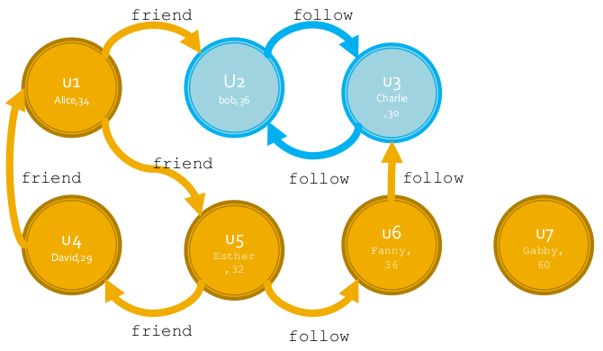

Pay attention that two paths are returned:

- $u2 \rightarrow \text{follow} \rightarrow u3 \rightarrow \text{follow} \rightarrow u2$
- $u3 \rightarrow \text{follow} \rightarrow u2 \rightarrow \text{follow} \rightarrow u3$

The content of the returned Dataframe is the following

| $v1$ | $e1$ | $v2$ | $e2$ |
| --- | --- | --- | --- |
| $[u2, \text{Bob}, 36]$ | $[u2, u3, \text{follow}]$ | $[u3, \text[Charlie], 30]$ | $[u3, u2, \text{follow}]$ |
| $[u3, \text[Charlie], 30]$ | $[u3, u2, \text{follow}]$ | $[u2, \text{Bob}, 36]$ | $[u2, u3, \text{follow}]$ |

- There is one column for each (distinct) named vertex and edge of the structural pattern;
- The records are associated with the vertexes and edges of the selected paths;
- All columns are associated with the data type “struct”. Each struct has the same “schema/features” of the associated vertex or edge.

```python
from graphframes import GraphFrame

# Vertex DataFrame
v = spark.createDataFrame(
    [
        ("u1", "Alice", 34),
        ("u2", "Bob", 36),
        ("u3", "Charlie", 30),
        ("u4", "David", 29),
        ("u5", "Esther", 32),
        ("u6", "Fanny", 36),
        ("u7", "Gabby", 60)
    ],
    ["id", "name", "age"]
)

# Edge DataFrame
e = spark.createDataFrame(
    [
        ("u1", "u2", "friend"),
        ("u2", "u3", "follow"),
        ("u3", "u2", "follow"),
        ("u6", "u3", "follow"),
        ("u5", "u6", "follow"),
        ("u5", "u4", "friend"),
        ("u4", "u1", "friend"),
        ("u1", "u5", "friend")
    ],
    ["src", "dst", "relationship"]
)

# Create the graph
g = GraphFrame(v, e)

# Retrieve the motifs associated with the pattern
# vertex -> edge -> vertex -> edge ->vertex
motifs = g.find("(v1)-[e1]->(v2); (v2)-[e2]->(v1)")
```

**Example 2**

Given the following graph

Find the paths/subgraphs matching the pattern

$$(v1) - [\text{friend}] \rightarrow (v2);\quad (v2) - [\text{follow}] \rightarrow (v3)$$

Store the result in a DataFrame

First selected path

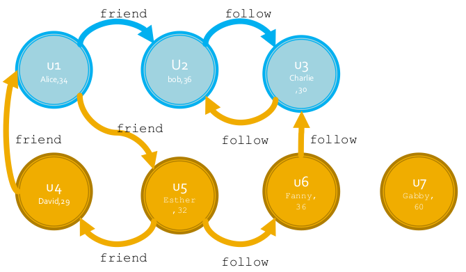

Second selected path

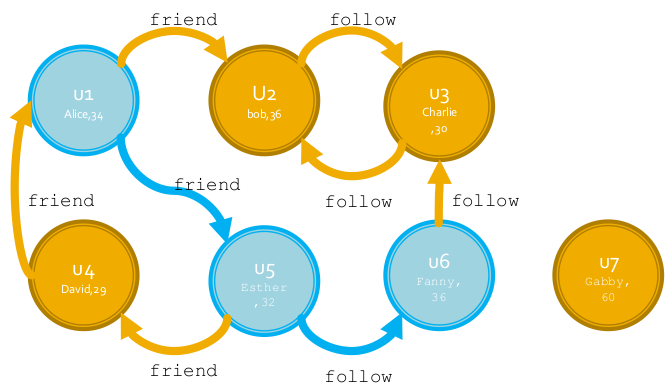

```python
from graphframes import GraphFrame

# Vertex DataFrame
v = spark.createDataFrame(
    [
        ("u1", "Alice", 34),
        ("u2", "Bob", 36),
        ("u3", "Charlie", 30),
        ("u4", "David", 29),
        ("u5", "Esther", 32),
        ("u6", "Fanny", 36),
        ("u7", "Gabby", 60)
    ],
    ["id", "name", "age"]
)

# Edge DataFrame
e = spark.createDataFrame(
    [
        ("u1", "u2", "friend"),
        ("u2", "u3", "follow"),
        ("u3", "u2", "follow"),
        ("u6", "u3", "follow"),
        ("u5", "u6", "follow"),
        ("u5", "u4", "friend"),
        ("u4", "u1", "friend"),
        ("u1", "u5", "friend")
    ],
    ["src", "dst", "relationship"]
)

# Create the graph
g = GraphFrame(v, e)

# Retrieve the motifs associated with the pattern
# vertex -> edge -> vertex -> edge ->vertex
motifs = g.find("(v1)-[friend]->(v2); (v2)-[follow]->(v3)")

# Filter the motifs (the content of the motifs DataFrame)
# Select only the ones matching the pattern
# vertex -> friend-> vertex -> follow ->vertex
motifsFriendFollow = motifs \
    .filter("friend.relationship='friend' AND follow.relationship='follow' ") # <1>
```

1. Columns friend and follow are structs with three fields/attributes: “src”, “dst”, “relationship”. To access a field of a struct column use the syntax `columnName.field` (e.g., `friend.relationship`)

# 4 Basic statistics

Some specific properties are provided to compute basic statistics on the degrees of the vertexes

- `degrees`
- `inDegrees`
- `outDegrees`

The returned result of each of this property is a DataFrame with id and (in/out)Degree value.

## 4.1 `degrees`

`degrees` returns the degree of each vertex (i.e., the number of edges associated with each vertex). The result is stored in a DataFrame with Columns (vertex) “id” and “degree”, with one record per vertex. Only the vertexes with $\text{degree} \geq 1$ are stored in the returned DataFrame.

## 4.2 `inDegrees`

`inDegrees` returns the in-degree of each vertex (i.e., the number of in-edges associated with each vertex). The result is stored in a DataFrame with Columns (vertex) “id” and “inDegree”, with one record per vertex. Only the vertexes with $\text{in-degree} \geq 1$ are stored in the returned DataFrame.

## 4.3 `outDegrees`

`outDegrees` returns the out-degree of each vertex (i.e., the number of out-edges associated with each vertex). The result is stored in a DataFrame with Columns (vertex) “id” and “outDegree”, with one record per vertex. Only the vertexes with $\text{out-degree} \geq 1$ are stored in the returned DataFrame.

**Example 1**

Given the input graph, compute

- Degree of each vertex
- inDegree of each vertex
- outDegree of each vertex

```python
from graphframes import GraphFrame

# Vertex DataFrame
v = spark.createDataFrame(
    [
        ("u1", "Alice", 34),
        ("u2", "Bob", 36),
        ("u3", "Charlie", 30),
        ("u4", "David", 29),
        ("u5", "Esther", 32),
        ("u6", "Fanny", 36),
        ("u7", "Gabby", 60)
    ],
    ["id", "name", "age"]
)

# Edge DataFrame
e = spark.createDataFrame(
    [
        ("u1", "u2", "friend"),
        ("u2", "u3", "follow"),
        ("u3", "u2", "follow"),
        ("u6", "u3", "follow"),
        ("u5", "u6", "follow"),
        ("u5", "u4", "friend"),
        ("u4", "u1", "friend"),
        ("u1", "u5", "friend")
    ],
    ["src", "dst", "relationship"]
)

# Create the graph
g = GraphFrame(v, e)

# Retrieve the DataFrame with the information about the degree of
# each vertex
vertexesDegreesDF = g.degrees

# Retrieve the DataFrame with the information about the in-degree of
# each vertex
vertexesInDegreesDF = g.inDegrees

# Retrieve the DataFrame with the information about the out-degree of
# each vertex
vertexesOutDegreesDF = g.outDegrees
```

**Note**

Given the input graph, select only the ids of the vertexes with at least 2 in-edges.

First selected vertex

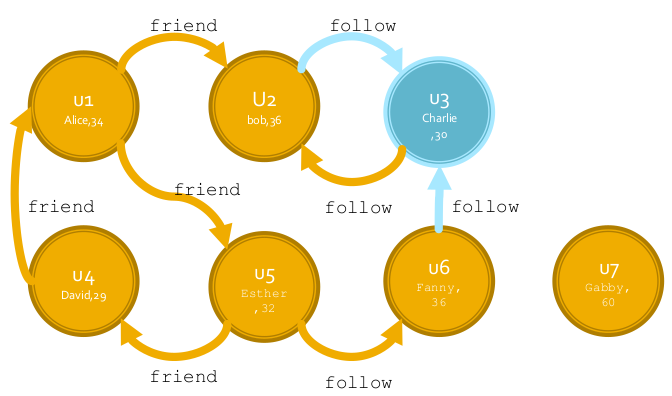

Second selected vertex

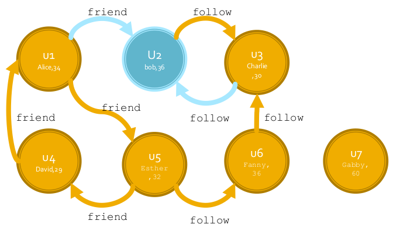

Resulting vertexes

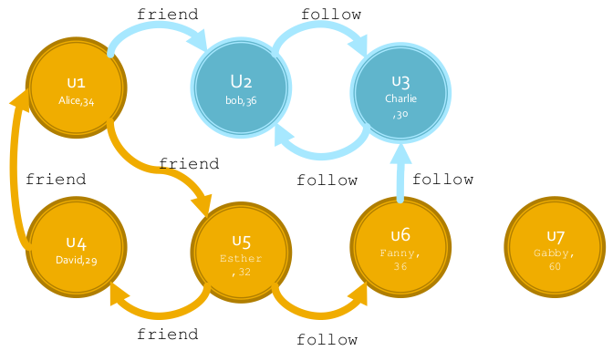

The selected IDs are $u2$ and $u3$

```python
from graphframes import GraphFrame

# Vertex DataFrame
v = spark.createDataFrame(
    [
        ("u1", "Alice", 34),
        ("u2", "Bob", 36),
        ("u3", "Charlie", 30),
        ("u4", "David", 29),
        ("u5", "Esther", 32),
        ("u6", "Fanny", 36),
        ("u7", "Gabby", 60)
    ],
    ["id", "name", "age"]
)

# Edge DataFrame
e = spark.createDataFrame(
    [
        ("u1", "u2", "friend"),
        ("u2", "u3", "follow"),
        ("u3", "u2", "follow"),
        ("u6", "u3", "follow"),
        ("u5", "u6", "follow"),
        ("u5", "u4", "friend"),
        ("u4", "u1", "friend"),
        ("u1", "u5", "friend")
    ],
    ["src", "dst", "relationship"]
)

# Create the graph
g = GraphFrame(v, e)

# Retrieve the DataFrame with the information about the in-degree of
# each vertex
vertexesInDegreesDF = g.inDegrees

# Select only the vertexes with and in-degree value >=2
selectedVertexesDF = vertexesInDegreesDF.filter("inDegree>=2")

# Select only the content of Column id
selectedVertexesIDsDF = selectedVertexesDF.select("id")
```